# Лабораторна робота 4

# Тема. Рекурсія. Стратегія «розділяй і володарюй»

# Мета: засвоїти технологію реалізації рекурсивних алгоритмів засобами Python і оцінювання їх складності з використанням головної теореми рекурсії.

## 1.Факторіал на мові Python:

```python
def FacSimple(n):
    #Обчислення факторіала за допомогою цикла while
    factorial = 1
    i = 1
    while i <= n:
         factorial *= i
         i += 1
    return factorial
```

## 2.Реалізувати процедуру обчислення факторіалу за допомогою циклу for та оцінка асимптотичну складність алгоритму.

1. Кількість ітерацій в циклі пропорційна n.
2. На кожній ітерації виконується одна операція множення.

Складність алгоритму 𝑂(𝑛) (лінійна), тому що кількість операцій зростає пропорційно розміру n.

```python
def factorial(n):
    result = 1
    for i in range(2, n + 1):
        result *= i
    return result
```

## 3.Оцінка асимптотичну складність рекурсивного алгоритму обчислення факторіалу.

```python
def fac(n):
    # Обчислення факторіала через рекурсію
    if n == 0:
        return(1)
    return fac(n-1) * n
```

1. Кількість викликів функції прямо залежить від значення 𝑛, тобто алгоритм здійснює 𝑛 рекурсивних викликів.
2. Операції множення та присвоєння виконуються на кожному рівні рекурсії.

Складність рекурсивного алгоритму обчислення факторіалу становить 𝑂(𝑛),оскільки кількість операцій пропорційна 𝑛.

## 4.Рекурсивного алгоритму обчислення на мові Python:

```python
def fibonacci(n):

    #Рекурсивне обчислення n-го числа Фібоначчі
    if n == 0:
        return 0
    if n in (1, 2):
        return 1
    return fibonacci(n - 1) + fibonacci(n - 2)
```

## 5.Оцінка асимптотичну складність рекурсивного алгоритму обчислення n-го числа Фібоначчі.

1. Кожен виклик функції генерує два нових виклики (для 𝑛−1та 𝑛−2), створюючи дерево викликів.
2. Глибина цього дерева дорівнює 𝑛, а загальна кількість викликів функції є приблизно експоненційною.

Отже,складність цього алгоритму становить 𝑂($2^n$),оскільки кількість рекурсивних викликів збільшується експоненційно зі зростанням 𝑛.

## 6.Сортування злиттям на мові Python:

```python
def merge(left, right):

    #Зливає два відсортованих масиви left і right у один

    result = []
    i, j = 0, 0
    while i < len(left) and j < len(right):
        if left[i] <= right[j]:
            result.append(left[i])
            i += 1
        else:
            result.append(right[j])
            j += 1
    result += left[i:]
    result += right[j:]
    return result
def mergesort(list):

    #Рекурсивна функція сортування з використанням попередньої функції

    if len(list) < 2:
        return list
    middle = len(list) // 2
    left = mergesort(list[:middle])
    right = mergesort(list[middle:])
    return merge(left, right)
```

## 7.Оцінити асимптотичну складність алгоритму сортування злиттям, використовуючи головну теорему рекурсії.

Застосування головної теореми рекурсії: Рівняння має вигляд

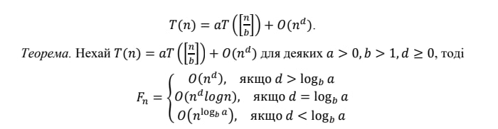

Якщо 𝑝=𝑑,тому складність алгоритму становить:𝑂(𝑛log𝑛).

## 8.Відповіді на запитання:

1. Надати визначення складності задачі із символом Ω.

Складність задачі із символом Ω Складність задачі з використанням символу Ω писує мінімальну кількість ресурсів (час або пам'ять), необхідних для виконання алгоритму в найкращому випадку. Наприклад, якщо алгоритм має складність Ω(𝑛), це означає, що неможливо виконати його швидше за лінійний час для завдання розміру 𝑛.

2. Функція часової складності має вигляд: F(N) = $𝑁^3$ + 7$𝑁^2$ − 14N. Як записати асимптотичну складність у O-нотації?

O-нотація оцінює верхню межу складності, тому нас цікавить термін, який зростає найшвидше при великих N. $𝑁^3$ зростає швидше за $𝑁^2$ і 𝑁. Тому,7$𝑁^2$і −14𝑁 можна знехтувати Отже,O($N^3$)

3. Функція часової складності має вигляд: F(N) = 1.01N + $𝑁^{10}$ Як записати асимптотичну складність у O-нотації?

N¹⁰ зростає набагато швидше, ніж N. Тому,1.01N можна знехтувати Отже,O($N^{10}$)

4. Функція часової складності має вигляд: F(N) = $𝑁^{1.3}$ + 10 log2N.Як записати асимптотичну складність у O-нотації?

$𝑁^1.3$ зростає набагато швидше, ніж log2N Тому,log2N можна знехтувати Отже,O($𝑁^{1.3}$)

5. У чому полягає ідея розпаралелювання обчислень і для чого вона використовується?

Ідея розпаралелювання обчислень Розпаралелювання обчислень полягає у виконанні кількох частин завдання одночасно, використовуючи багатоядерні процесори чи розподілені системи. Це дозволяє: Скоротити час виконання великих завдань. Збільшити продуктивність системи. Використовується для задач, які можна розділити на незалежні підзадачі. З алгоритмів лабораторної роботи, сортування злиттям дозволяє розпаралелювання, оскільки підмасиви можуть бути сортувані незалежно.

6. Які існують способи підвищення обчислювальної швидкості алгоритмів? Який з них є найефективнішим?

Оптимізація коду (зменшення кількості зайвих операцій). Використання ефективних структур даних (наприклад, хеш-таблиці чи дерева). Алгоритмічна оптимізація (перехід до алгоритмів з меншою складністю). Розпаралелювання (запуск на кількох ядрах або комп’ютерах). Найефективним є підхід, який забезпечує оптимальне поєднання всіх методів для конкретної задачі.